# MTH6139 Time Series

Coursework 1 – 230097319

Amal Abdirahman

Spring term 2026

# Overview

I used Meta’s Prophet to analyse and forecast atmospheric PM2.5 concentrations in Beijing. This dataset contains PM2.5 data of the US Embassy in Beijing, recorded between January 2010 and December 2014.

An initial visual analysis revealed a highly seasonal pattern with massive pollution spikes occurring during the winter months, contrasted by lower concentrations in the summer. To address these complexities, the Prophet model was deployed across three iterations: a baseline model, a holiday-adjusted model to account for the Lunar New Year, and a log transformed model to stabilise the extreme variance observed in the historical data.

[figure not shown]

Beijing

# 1 R Libraries

I used these libraries in my project.

```r
library(dplyr)
library(lubridate)
library(prophet)
```

```r
library(ggplot2)
```

# 2 Data Preparation

Before modelling the data, it must be cleaned and transformed to a specific format to fit prophet. Prophet requires a `dataframe` (not a `ts` object) with two specific columns: `ds` (datestamp) and `y`.

**Why dplyr and lubridate?**

While using the basic R syntax was possible, I found it to be quite confusing to understand and using `dplyr` was better suited for its readability and it being easier to use. I used `lubridate` to handle the complexities of date conversion, as prophet can only work if formatted as YYYY-MM-DD. The dataset had entries per hour, per day from 2010 to 2014, converting ‘year’, ‘month’, ‘date’ into a single `Date`, made the data suitable for Prophet.

```r
# Load the air quality data
beijing_raw <- read.csv("data/PRSA_data_2010.1.1-2014.12.31.csv")

# Clean the Data (using dplyr)
beijing_data <- beijing_raw %>%
    # Create Date object and and deal with blank values
    mutate(
        ds = make_date(year, month, day),
        pm2.5 = ifelse(pm2.5 == -999, NA, pm2.5)
    ) %>%
    # Aggregate to daily averages
    group_by(ds) %>%
    summarise(
        y_raw = mean(pm2.5, na.rm = TRUE),
        .groups = "drop"
    ) %>%
    # Remove blank days and arrange it chronologically
    filter(!is.na(y_raw)) %>%
    arrange(ds)
#formatting for prophet
prophet_basic_data <- data.frame(ds = beijing_data$ds, y = beijing_data$y_raw)
```

# 3 Model 1: Basic Prophet Forecast

I first trialled Prophet on the model just to see how Prophet works, and how well it works with this data

```r
#Fit basic model
basic_model<-prophet(prophet_basic_data)
```

```
## Disabling daily seasonality. Run prophet with daily.seasonality=TRUE to override this.
```

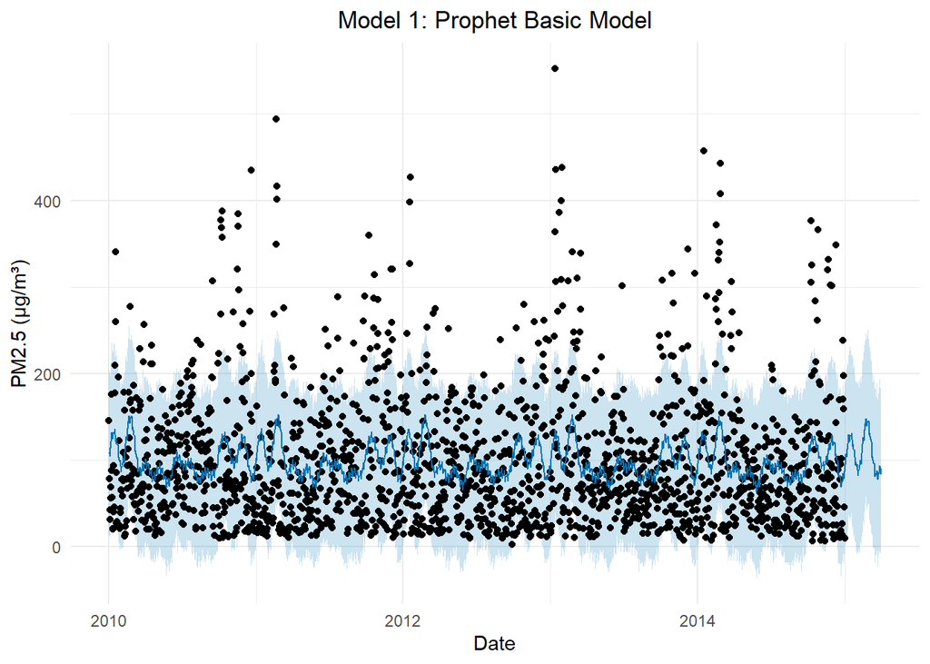

```r
# Forecast
future_basic <- make_future_dataframe(basic_model, periods = 90)
forecast_basic <- predict(basic_model, future_basic)


# Plot the baseline model
plot(basic_model, forecast_basic) +
    ggtitle("Model 1: Prophet Basic Model") +
    xlab("Date") +
    ylab("PM2.5 (μg/m³)") +
    theme_minimal() +
    theme(plot.title = element_text(hjust = 0.5))
```

The **black dots** represent the actual PM2.5 readings. The **dark blue line** (`yhat`) is Prophet’s best guess of the trend. The **light blue band** represents the 80% Prediction Interval.

# 4 Model 2: Adding Context to the Model

In Beijing, the Lunar New Year triggers a massive, temporary surge in PM2.5 due to widespread fireworks, followed immediately by a dramatic drop as factories and businesses shut down for the holiday week. We add `holidays` data frame into the model to show this.

```r
# Create the holiday dataframe
chinese_new_year <- data.frame(
    holiday = "chinese_new_year",
    ds = as.Date(c("2010-02-14", "2011-02-03", "2012-01-23",
                   "2013-02-10", "2014-01-31")),
    lower_window = -1, #The day before
    upper_window = 2 #The day after
)
# Run the model with holidays
prophet_model2 <- prophet(prophet_basic_data, holidays = chinese_new_year)
```

```
## Disabling daily seasonality. Run prophet with daily.seasonality=TRUE to override this.
```

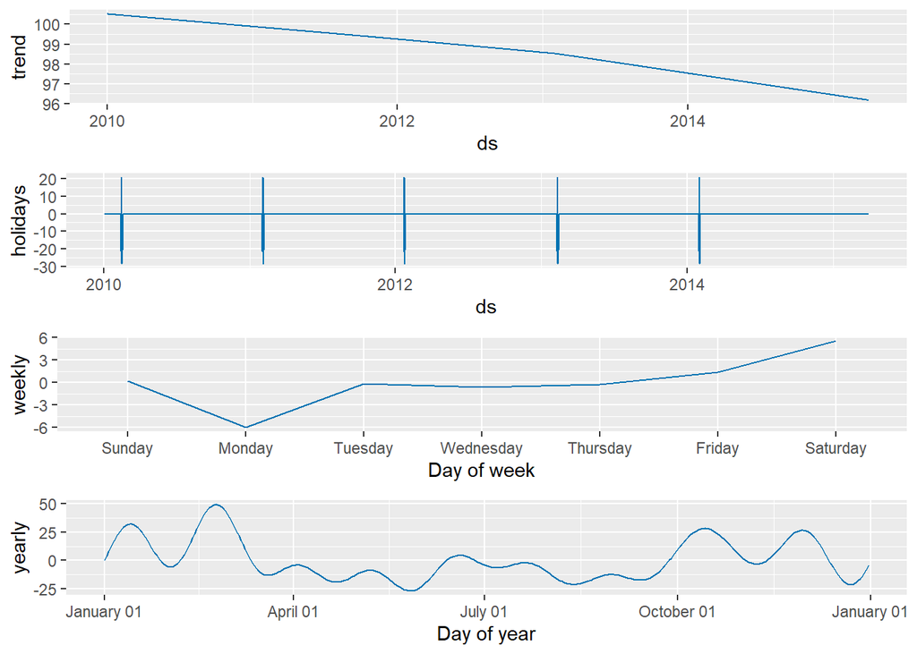

```r
future_model2 <- make_future_dataframe(prophet_model2, periods = 90)
forecast_model2 <- predict(prophet_model2, future_model2)

# Plot the components
prophet_plot_components(prophet_model2, forecast_model2)
```

The **trend panel**: this shows a downward trend in the baseline PM2.5 levels from 2010 to 2014. This aligns with the introduction of China’s aggressive “Air Pollution Prevention and Control Action Plan” implemented around 2013, which aimed to drastically reduce coal reliance in the capital.

The **holiday panel**: this proves that our new addition works. There’s a spike on the exact dates on Chinese New Year, following a crash from the factory shutdown for the holidays.

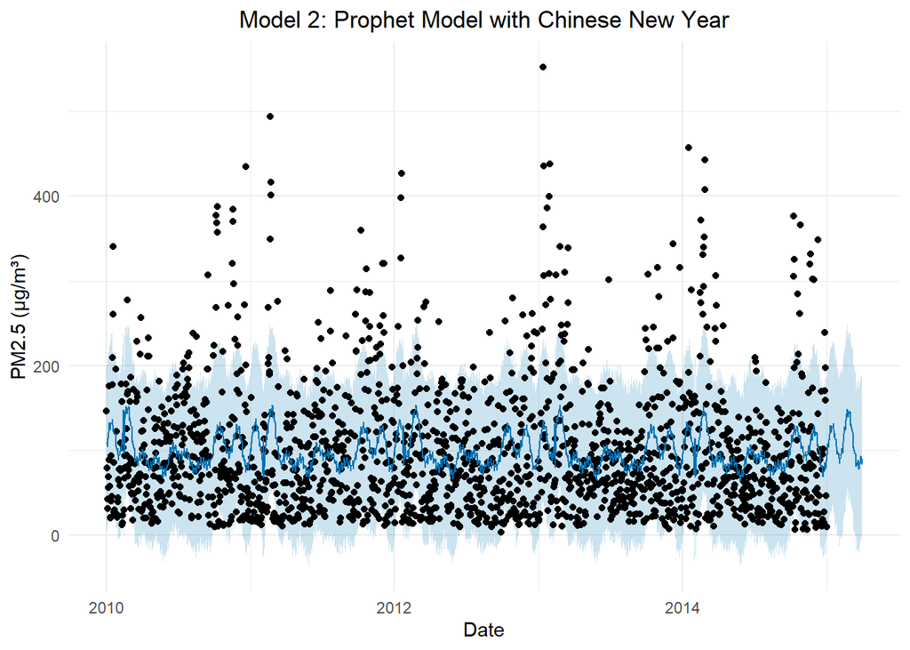

```r
plot(prophet_model2, forecast_model2) +
    ggtitle("Model 2: Prophet Model with Chinese New Year") +
    xlab("Date") +
    ylab("PM2.5 (μg/m³)") +
    theme_minimal() +
    theme(plot.title = element_text(hjust = 0.5))
```

Model 2 understands the timing of the spikes, but the variance is too extreme for the blue band to cover the winter peaks. This requires a log transformation.

# 5 Model 3: Log Transformed Model

To address the heteroscedasticity observed in the previous plots, a log transformation was applied. This stabilises the variance across seasons. The final plot back transforms the values using `expm1()`

```r
#Dealing with Heteroscedacity
#Apply log transformation
prophet_data2 <- beijing_data %>%
    mutate(y = log1p(y_raw))
##Initialise the model (keeping Chinese New Year)
prophet_log_model <- prophet(
    holidays = chinese_new_year,
    seasonality.mode = "additive" # Must be additive because the data is logged
)

# Fit the model to our logged data
prophet_log_model <- fit.prophet(prophet_log_model, prophet_data2)
```

```
## Disabling daily seasonality. Run prophet with daily.seasonality=TRUE to override this.
```

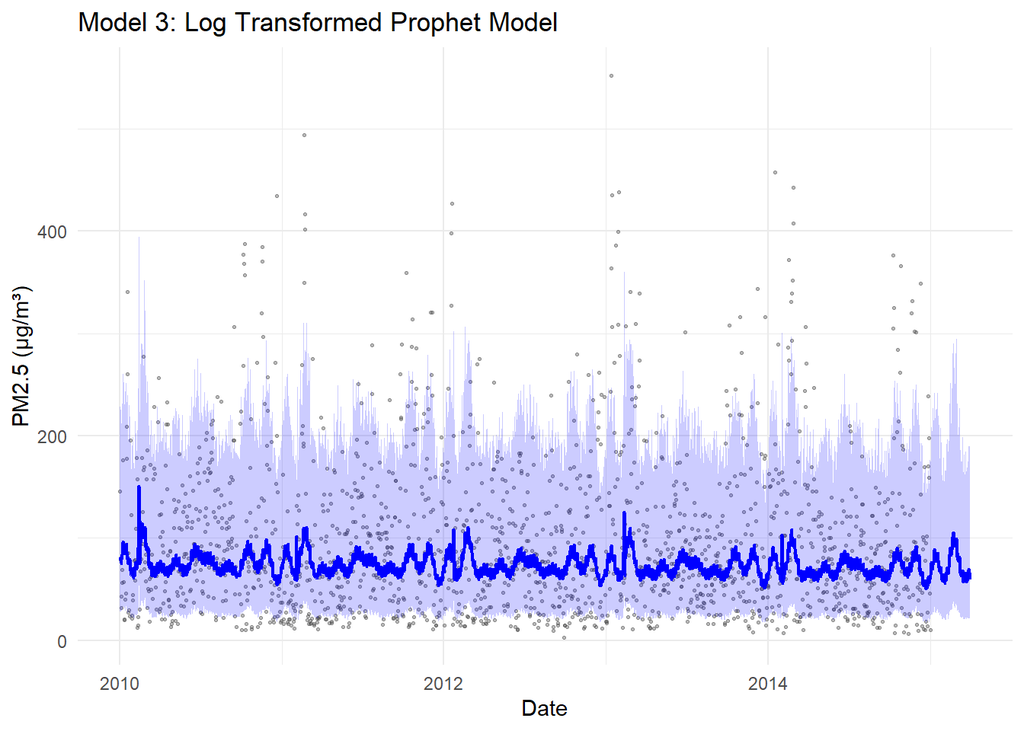

```r
#Forecast 90 days into the future
future_log_model <- make_future_dataframe(prophet_log_model, periods = 90)
forecast_pro <- predict(prophet_log_model, future_log_model)

# Plot
# We use expm1() to reverse the log1p() so its easier to read
ggplot() +
    # The actual data points (semi-transparent grey)
    geom_point(data = prophet_data2, aes(x = as.Date(ds), y = expm1(y)),
               color = "gray30", size = 0.5, alpha = 0.4) +
    # The blue confidence interval
    geom_ribbon(data = forecast_pro, aes(x = as.Date(ds), ymin = expm1(yhat_lower), ymax = expm1(yhat_upper)),
                fill = "blue", alpha = 0.2) +
    # The blue forecast line
    geom_line(data = forecast_pro, aes(x = as.Date(ds), y = expm1(yhat)),
              color = "blue", linewidth = 0.8) +
    ggtitle("Model 3: Log Transformed Prophet Model") +
    ylab("PM2.5 (μg/m³)") +
    xlab("Date") +
    theme_minimal()
```

Now the prediction interval contains more data points, which is much more representative compared to the second model.

# Conclusion

Prophet allowed us to explore many insights from the data, especially how cultural events are vital to acknowledge for forecasting environmental data.

**How to Improve the Model:**

- Including weather factors: PM2.5 is also influenced by the weather. We could add daily wind speed or air pressure into the model which allows the model to predict when air traps pollution over the city.
- Using Air Quality Index (AQI) API: This dataset ends in 2014. Using current data means you could discover different trends in the data e.g the effect of COVID-19 pandemic.

# References

- Beijing PM2.5 dataset https://archive.ics.uci.edu/dataset/381/beijing+pm2+5+data
- Datacamp course: https://www.datacamp.com/courses/reporting-with-rmarkdown
- RStudio reference: https://rmarkdown.rstudio.com/lesson-1.html
- R Markdownhttps://bookdown.org/yihui/rmarkdown/
- Meta’s Prophet Github https://facebook.github.io/prophet/docs/quick_start.html#r-api
- ggplot2 https://rstudio.github.io/cheatsheets/html/data-visualization.html
- dplyr in R - DataDaft https://www.youtube.com/watch?v=THGFXV4RW8U&list=PLiC1doDIe9rC8RgWPAWqDETE-VbKOWfWl
- lubridate in R https://rstudio.github.io/cheatsheets/html/lubridate.html